# Decomposição da participação brasileira no turismo receptivo internacional: Análise shift-share sobre chegadas e receitas turísticas

## 1 Contexto OE1

| OE | Perguntas de pesquisa | Materiais | Métodos |
| --- | --- | --- | --- |
| OE1.1 | Como evoluiu a participação do Brasil no turismo internacional entre 2010 e 2024 em comparação a destinos concorrentes? | OMT/WB | Shift-Share |
| OE1.2 | Há diferenças na evolução da participação do Brasil em mercados emissores mais sensíveis às mudanças climáticas? | OMT/OCDE | Shift-Share |
| OE1.3 | Quais fatores estruturais e conjunturais explicam variações no desempenho do Brasil em termos de chegadas e receitas? | OMT/WB | Shift-Share |
| OE1.4 | Em que medida choques externos (megaeventos, recessões, pandemia) afetaram a competitividade internacional do turismo brasileiro? | OMT/WB | Event Study |

## 2 Análise shift-share

Since the **early 1960s**, the SSA has been applied in **many fields**, such as spatial economics (Curtis, 1972), political economics (Glickman & Glasmeier, 1989), geography (Plane, 1987), urban planning (Stilwell, 1969), and international trade (Cheptea et al., 2005).

From an economic theoretical perspective, application of the shift-share technique in alternative contexts can demonstrate its efficacy and adaptability in **analyzing the changes in tourism development in a particular country or region based on the global economic growth, global industry growth, and global competitive growth**.

Tourism development in a country can be attributed to the aggregate of three indicators, which we term as:

- the **global growth effect** (GGE):

  measures tourism development in a country that would have occurred in the country if tourism had developed equivalent to the development of the global economy.

  The GGE shows the extent to which tourism development in the country is attributable to the overall economic development in the world.
- the **global industrial mix effect** (GIME):

  links the differential rate of growth in tourism development in the country under investigation to the weaknesses and strengths of the global tourism industry
- the **global competitive share effect** (GCSE).

  measures the extent to which tourism development is driven by the country’s competitiveness in the tourism industry. That is, this measure indicates whether the country under examination (e.g., The United States) is relatively competitive in capturing a greater share of tourist arrivals and/or tourism receipts compared with the capture rate of other countries in the world.

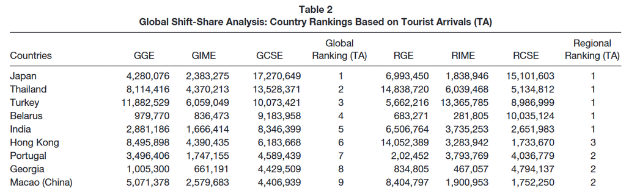

Dogru et al, 2021

**Fonte**

Dogru, T., Suess, C., & Sirakaya-Turk, E. (2021). Why do some countries prosper more in tourism than others? Global competitiveness of tourism development. Journal of Hospitality & Tourism Research, 45(1), 215–256. https://doi.org/10.1177/1096348020911706

## 3 Dados

- ONU Turismo
  - UN Tourism Data Dashboard: https://www.untourism.int/tourism-data/un-tourism-tourism-dashboard
  - Tourism Statistics Database: https://www.untourism.int/tourism-statistics/tourism-statistics-database
- Qualidade ruim: ausência de dados de anos e de países.
- Não consegui checar com resultados anuais publicados.
- Usei período 2003 a 2019.

## 4 Resultados sobre chegadas turísticas internacionais

### 4.1 Importação dos dados

```r
# Shift-share dinâmico (turismo receptivo) com REAT::shiftd ----
rm(list = ls(all=T))
library(tidyverse)
library(magrittr)
library(REAT)
library(readxl)

pais_alvo <- "Brazil"

# Importa dados da OMT ---
path <- "data/UN_Tourism_inbound_arrivals_by_region_10_2025.xlsx"
bd_raw <- readxl::read_excel(path,
                             sheet = "Data",
                             col_types = c("text", "text", "text", "numeric", "text", "numeric",
                                           "text","numeric","numeric","text","text","text",
                                           "text","text")) |>
          janitor::clean_names()
```

### 4.2 Preparação dos dados

```r
# Total de turistas por país e ano ----
bd_pa <- bd_raw |>
  filter(is.na(partner_area_label) | partner_area_label != "World") |>
  summarise(turistas = sum(value), .by = c(reporter_area_label, year)) |>
  rename(pais = reporter_area_label,
         ano = year)

# Número de observações por país
bd_pa |> count(pais) |> group_by(n) |> count() |> print(n=Inf)
```

```
# A tibble: 23 × 2
# Groups:   n [23]
       n    nn
   <int> <int>
 1     3     1
 2     7     1
 3     9     1
 4    11     4
 5    12     1
 6    13     2
 7    14     1
 8    15     1
 9    16     4
10    17     2
11    18     2
12    19     4
13    20     2
14    21     5
15    22     7
16    23    11
17    24     5
18    25     7
19    26    14
20    27    28
21    28    65
22    29     1
23    30    37
```

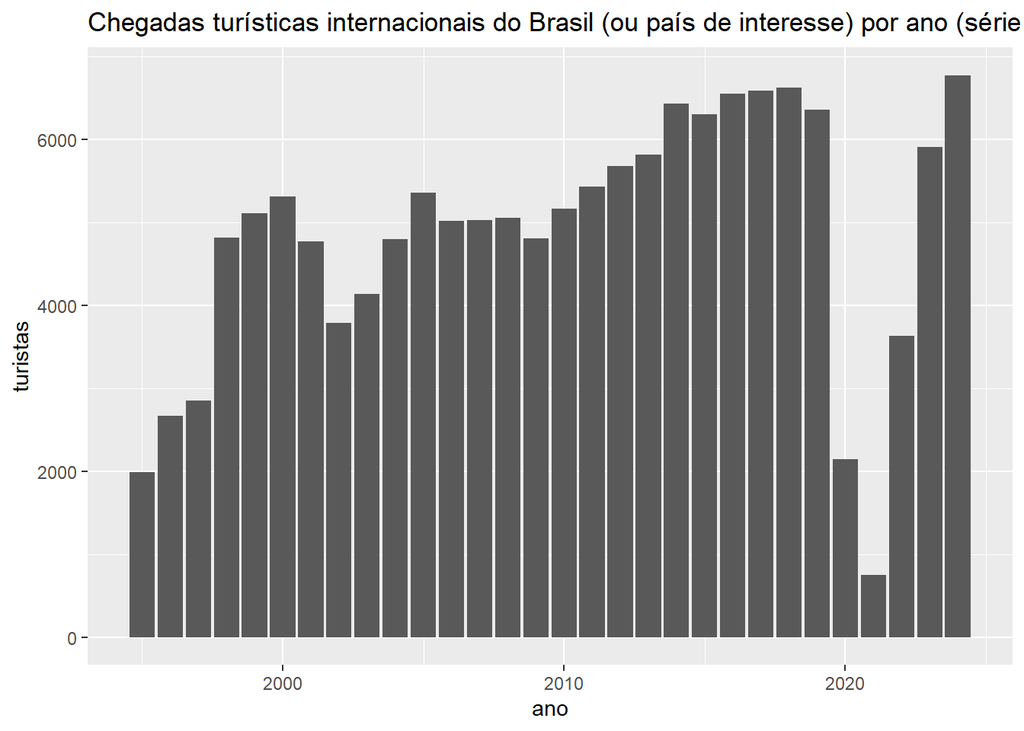

```r
# Visualização da série de um país para a amostra completa
bd_pa |> filter(pais == pais_alvo) |> ggplot(aes(x = ano, y = turistas)) +
  geom_bar(stat = "identity") +
  labs(title = "Chegadas turísticas internacionais do Brasil (ou país de interesse) por ano (série por país)")
```

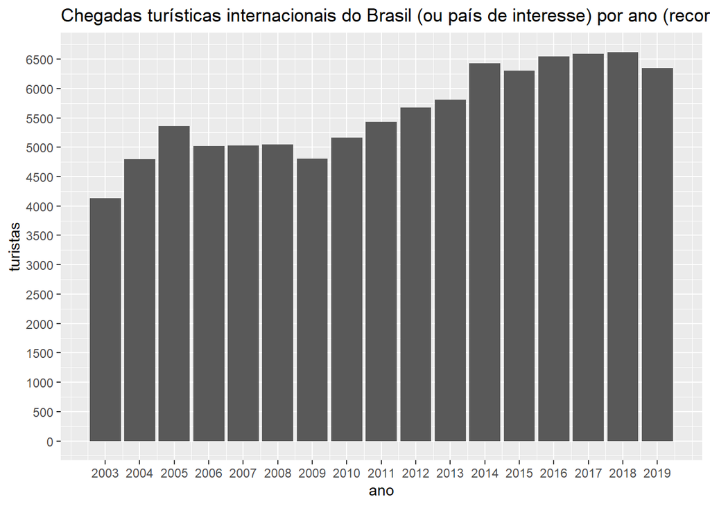

```r
# Limita ao período de análise ----
v_anos <- c(2003:2019)

# Visualização da série de um país para o período de análise
bd <- bd_pa |> filter(ano %in% v_anos)
bd |> filter(pais == pais_alvo) |> ggplot(aes(x = ano, y = turistas)) +
  geom_bar(stat = "identity") +
  scale_x_continuous(breaks = v_anos, labels = as.character(v_anos)) +
  scale_y_continuous(n.breaks = length(v_anos)) +
  labs(title = "Chegadas turísticas internacionais do Brasil (ou país de interesse) por ano (recorte temporal)")
```

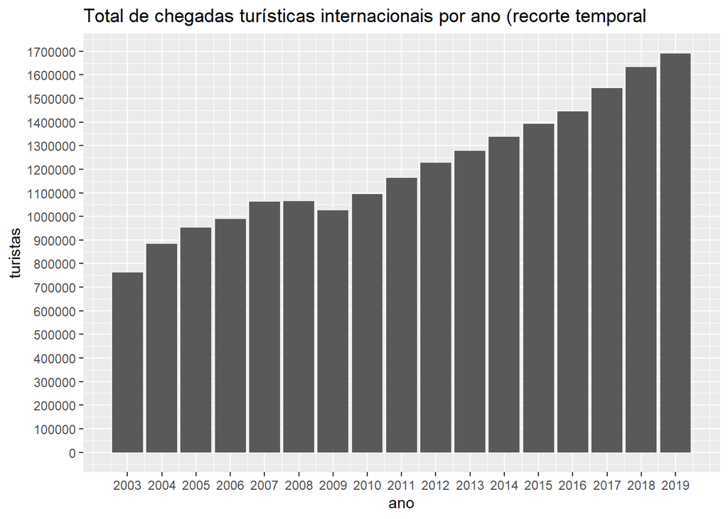

```r
# Série "mundo" ----
bd_mundo <- bd_pa |>
  summarise(turistas = sum(turistas, na.rm = TRUE), .by = ano) |>
  arrange(ano) |>
  filter(ano %in% v_anos)

# Visualização da série mundial para o período de análise
bd_mundo |> ggplot(aes(x = ano, y = turistas)) + geom_bar(stat = "identity") +
  scale_x_continuous(breaks = v_anos, labels = as.character(v_anos)) +
  scale_y_continuous(n.breaks = length(v_anos)) +
  labs(title = "Total de chegadas turísticas internacionais por ano (recorte temporal")
```

### 4.3 Análise Shift-Share

```
Dynamic Shift-Share Analysis
Method: Dunn

Shift-share components
                Components
Growth (t1-t)     2220.100
National share    4447.935
Industrial mix       0.000
Regional share   -2227.835
Net total shift  -2227.835

Calculation for 1 industries
Regional employment at time t: 4133, at time t+1: 6353.1 (2220.1 / 53.71643 %)
National employment at time t: 763129.6, at time t+1: 1691201 (928071.4 / 121.6139 %)
```

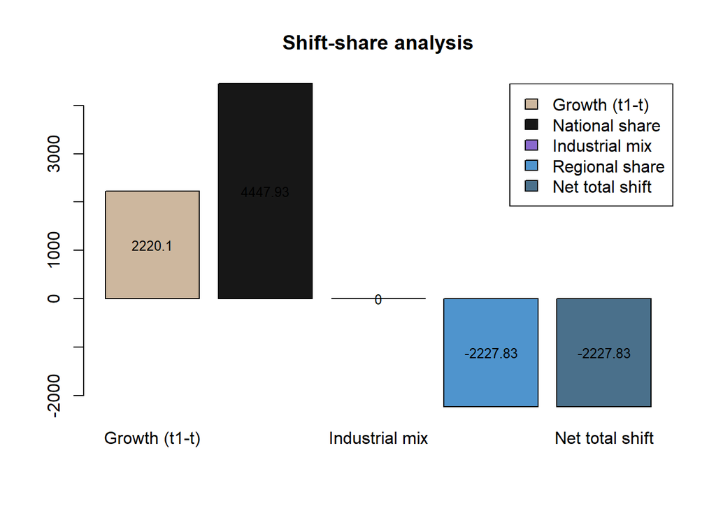

```r
# Parâmetros da análise
# a numeric vector with i values containing the employment in i industries in region j at time 1
e_ij1   <- bd |> filter(pais == pais_alvo, ano == 2003) |> pull(turistas)

# a numeric data frame or matrix with i rows containing the employment in i industries in region j and t columns, representing t (t>1) years
e_ij2   <- bd |> filter(pais == pais_alvo, ano > 2003) |>
  pivot_wider(values_from = turistas, names_from = ano) |>
  dplyr::select(-pais)|> as.data.frame()

# a numeric vector with i values containing the total employment in i industries at time 1
e_i1 <-  bd_mundo |> filter(ano == 2003) |> pull(turistas)


# a numeric data frame or matrix with i rows containing the total employment in i industries and t columns, representing t(t>11) years
e_i2    <- bd_mundo |> filter(ano > 2003) |>
  pivot_wider(values_from = turistas, names_from = ano) |>
  as.data.frame()

time1 <- min(v_anos)
time2 <- max(v_anos)

# Execução
res_ss_chegadas <- REAT::shiftd(e_ij1 = e_ij1,
                    e_ij2 = e_ij2,
                    e_i1  = e_i1,
                    e_i2  = e_i2,
                    time1 = time1,
                    time2 = time2,
                    shift.method = "Dunn",
                    print.results = TRUE, plot.results = TRUE)
```

## 5 Próximos passos

- Revisão da literatura
- Verificação detalhada dos dados da ONU Turismo
  - Conferir total e alguns países com números divulgados pela ONU Turismo em relatórios.
  - Avaliar impacto das “flags” e “notes” que a ONU Turismo indica para alguns dados.
  - Conferir com dados do Banco Mundial.
  - Expandir para período até 2024.
- Melhorias no modelo.
- Acréscimo de variáveis (PIB Global).
- Comparação do Brasil com países concorrentes.
- Identificar mercados emissores mais sensíveis às mudanças climáticas